# Analisis_Covid-19

# Regresión Lineal usando datos de muertes de contagios por el COVID-19

[figure not shown]

```
Ecuación:  y = 57.822256343865895x -1818.9531340339436
La predicción de 200 es:  9745.498134739235
```

```python
# Creamos el objeto de Regresión Lineal
regr = LinearRegression()
# Entrenamos nuestro modelo
#regr.fit(np.array(x).reshape(-1, 1) ,y)
regr.fit(x.reshape((-1, 1)),z)
#pred = regr.predict(np.array(x).reshape(-1, 1))
pred = regr.predict(x.reshape((-1, 1)))

plt.figure(figsize=(10, 10))
plt.scatter(x,z,color='black')
plt.grid(True)
plt.title('Regresión Lineal de casos nuevos');
plt.scatter(x,pred,color='yellow')
#plt.legend()
plt.show()

if (regr.intercept_ < 0):
    ecua='y = {}x {}'
else:
    ecua='y = {}x + {}'
print('Ecuación: ',ecua.format(regr.coef_[0],regr.intercept_))

#Número del dia de la cuantos contagiados hay por el covid
num = 200
new  =  np.array([int(num)])
prediccion  =  regr.predict(new.reshape(-1,1))
print("La predicción de",num, "es: "  ,  prediccion[0])
```

# -------------- Regresión Logarítmica --------------

# Usando datos de casos nuevos de contagios por el COVID-19

```python
from scipy.optimize import curve_fit
from sklearn.linear_model import LogisticRegression
def modelo_logistico(x,a,b):
    return a+b*np.log(x)

exp_fit = curve_fit(modelo_logistico,x,y)
exp_fit1 = curve_fit(modelo_logistico,x,z)

print(exp_fit)
print(" ")
print(exp_fit1)
```

```
(array([-446.45387554,  253.81600502]), array([[104244.84312108, -22124.2513417 ],
       [-22124.2513417 ,   4907.61524206]]))

(array([-10481.82124408,   3486.39542592]), array([[ 604709.26516529, -128339.5842676 ],
       [-128339.5842676 ,   28468.36684504]]))
```

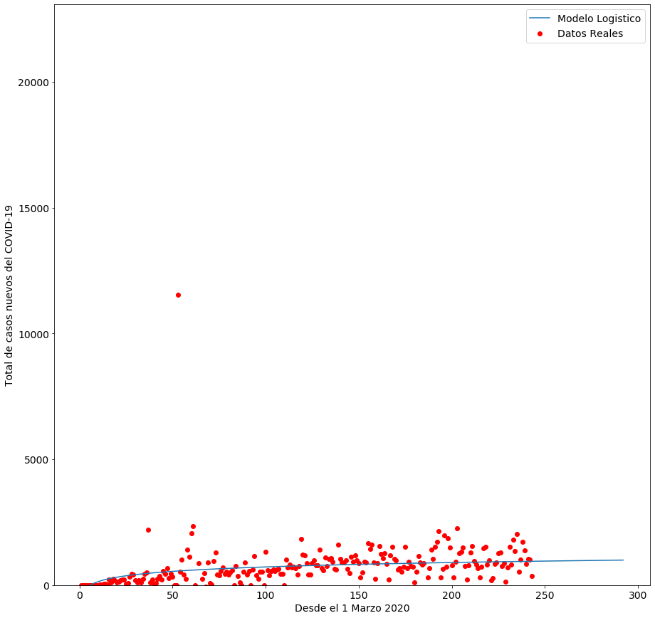

```python
pred_x = list(range(min(x),max(x)+50)) # Predecir 50 dias mas
plt.rcParams['figure.figsize'] = [15, 15]
plt.rc('font', size=14)
# Real data
plt.scatter(x,y,label="Datos Reales",color="red")
plt.plot(pred_x, [modelo_logistico(i,exp_fit[0][0],exp_fit[0][1]) for i in pred_x], label="Modelo Logistico" )
plt.legend()
plt.xlabel("Desde el 1 Marzo 2020")
plt.ylabel("Total de casos nuevos del COVID-19")
plt.ylim(0,max(y)*2)
plt.show()
```

# Usando datos de muertes por contagios de COVID-19

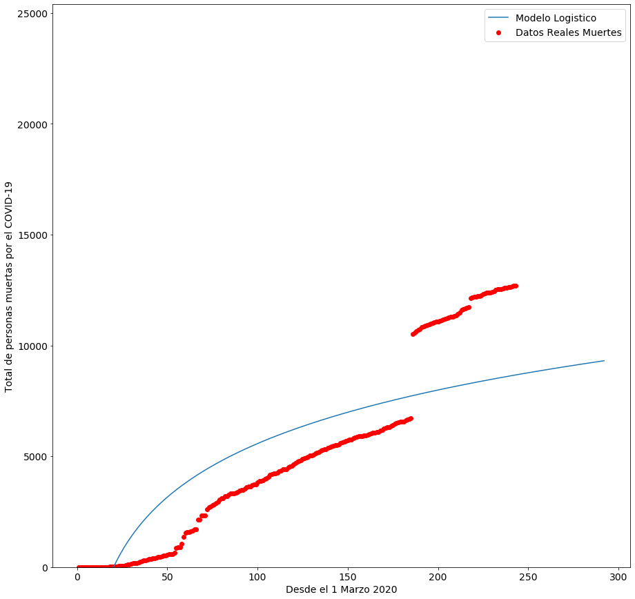

```python
plt.scatter(x,z,label="Datos Reales Muertes",color="red")
plt.plot(pred_x, [modelo_logistico(i,exp_fit1[0][0],exp_fit1[0][1]) for i in pred_x], label="Modelo Logistico" )
plt.legend()
plt.xlabel("Desde el 1 Marzo 2020")
plt.ylabel("Total de personas muertas por el COVID-19")
plt.ylim(0,max(z)*2) # Definir los limites de Y
plt.show()
```

# Análisis

Con el análisis de los datos pudimos observar la cantidad de casos nuevos y el total de muertes provocados por el virus en el Ecuador, se ve como esta en la actualidad el país con los contagios del COVID-19.

# Conclusión

# Criterio personal

### Político

Se debe tener presente las medidas de prevención contra el virus ya que así podremos evitar que se aumente los contagios en el país.

### Económico

Este virus ha afectado a varias empresas ya que por evitar el contagio deben cerrarse la cual, tambien en algunas empresas despedían a empleados por lo que estaba en stop el negocio y no generaban ingresos. El país presente grandes desequilibrios en dinero ya que por las restricciones se tiene una diferente manera de trabajar

### Social

Mediante este análisis podemos ver en qué estado se encuentra el país por lo que debemos seguir con las medidas de prevención contra el COVID-19 para así evitar contagios ya que en las gráficas se puede observar altos índices de casos nuevos y de numerosas muertes en el Ecuador.